# Exploratory Data Analysis of Physiological Signals

Jenna Lu

2026-07-27

# Overview

Physiological signals are dynamic measurements that contain temporal information about changes in human state.

This notebook performs exploratory analysis of electrocardiography (ECG) signals from the WESAD (Wearable Stress and Affect Detection) dataset prior to statistical modeling.

The goals are:

1. Inspect the structure of ECG recordings
2. Understand signal characteristics and recording duration
3. Visualize physiological signals over time
4. Examine experimental condition distributions
5. Prepare the data for downstream signal processing and functional analysis

# Libraries

```r
library(tidyverse)
library(here)
library(janitor)
```

# Load ECG Data

We begin with one participant (S2) to understand the structure of the physiological recordings.

```r
ecg_data <- read_csv(
  here("data", "processed", "S2_ecg.csv")
)
glimpse(ecg_data)
```

```
## Rows: 4,255,300
## Columns: 3
## $ time  <dbl> 0.000000000, 0.001428571, 0.002857143, 0.004285714, 0.005714286,…
## $ ecg   <dbl> 0.0214233398, 0.0203247070, 0.0165252686, 0.0167083740, 0.011672…
## $ label <dbl> 0, 0, 0, 0, 0, 0, 0, 0, 0, 0, 0, 0, 0, 0, 0, 0, 0, 0, 0, 0, 0, 0…
```

# Define Experimental Conditions

The WESAD dataset contains multiple physiological states represented by numerical labels. For interpretability, labels are converted into descriptive condition names.

```r
ecg_data <- ecg_data %>%
  mutate(
    condition = case_when(
      label == 0 ~ "Transient",
      label == 1 ~ "Baseline",
      label == 2 ~ "Stress",
      label == 3 ~ "Amusement",
      label == 4 ~ "Meditation",
      label == 6 ~ "Recovery",
      label == 7 ~ "Unknown"
    )
  )

count(ecg_data, condition)
```

```
## # A tibble: 7 × 2
##   condition        n
##   <chr>        <int>
## 1 Amusement   253400
## 2 Baseline    800800
## 3 Meditation  537599
## 4 Recovery     45500
## 5 Stress      430500
## 6 Transient  2142701
## 7 Unknown      44800
```

# Basic Summary

Summary statistics provide an overview of the ECG amplitude distribution and recording characteristics.

```r
summary(ecg_data)
```

```
##       time           ecg                label        condition
##  Min.   :   0   Min.   :-1.499542   Min.   :0.000   Length:4255300
##  1st Qu.:1520   1st Qu.:-0.067978   1st Qu.:0.000   Class :character
##  Median :3039   Median : 0.008240   Median :0.000   Mode  :character
##  Mean   :3039   Mean   : 0.001212   Mean   :1.212
##  3rd Qu.:4559   3rd Qu.: 0.044357   3rd Qu.:2.000
##  Max.   :6079   Max.   : 1.499313   Max.   :7.000
```

# Signal Length

The ECG recording contains measurements sampled at approximately 700 Hz.

```r
nrow(ecg_data)
```

```
## [1] 4255300
```

```r
max(ecg_data$time)
```

```
## [1] 6078.999
```

# Statistical Considerations

ECG measurements are collected repeatedly over time and therefore exhibit temporal dependence.

Individual ECG measurements should not be treated as independent observations. Instead, downstream analyses will use signal processing, feature extraction, and functional representations to summarize physiological responses while accounting for the structure of longitudinal data.

# Visualizing Raw ECG

The raw ECG waveform is visualized over the first five seconds of recording.

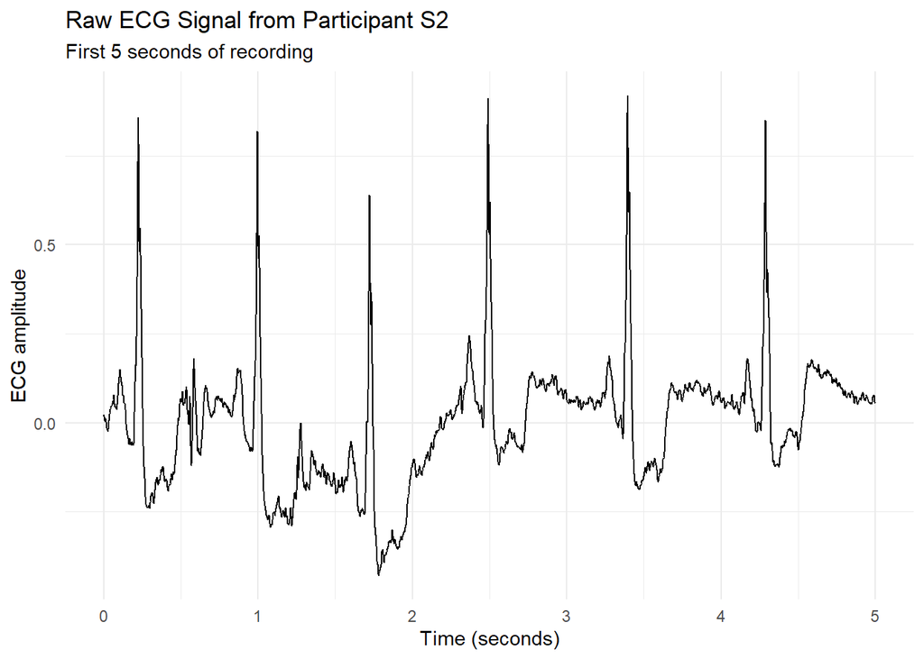

```r
ecg_data %>%
  slice(1:3500) %>%
  ggplot(
    aes(
      x = time,
      y = ecg
    )
  ) +
  geom_line() +
  labs(
    title = "Raw ECG Signal from Participant S2",
    subtitle = "First 5 seconds of recording",
    x = "Time (seconds)",
    y = "ECG amplitude"
  ) +
  theme_minimal()
```

# Condition Distribution

The number of observations in each physiological condition is examined to assess class balance.

```r
ecg_data %>%
  count(condition) %>%
  mutate(
    proportion = n / sum(n)
  )
```

```
## # A tibble: 7 × 3
##   condition        n proportion
##   <chr>        <int>      <dbl>
## 1 Amusement   253400     0.0595
## 2 Baseline    800800     0.188
## 3 Meditation  537599     0.126
## 4 Recovery     45500     0.0107
## 5 Stress      430500     0.101
## 6 Transient  2142701     0.504
## 7 Unknown      44800     0.0105
```

# ECG Signal Across Experimental Conditions

ECG recordings from baseline, stress, and amusement conditions are visualized to explore potential differences in physiological dynamics.

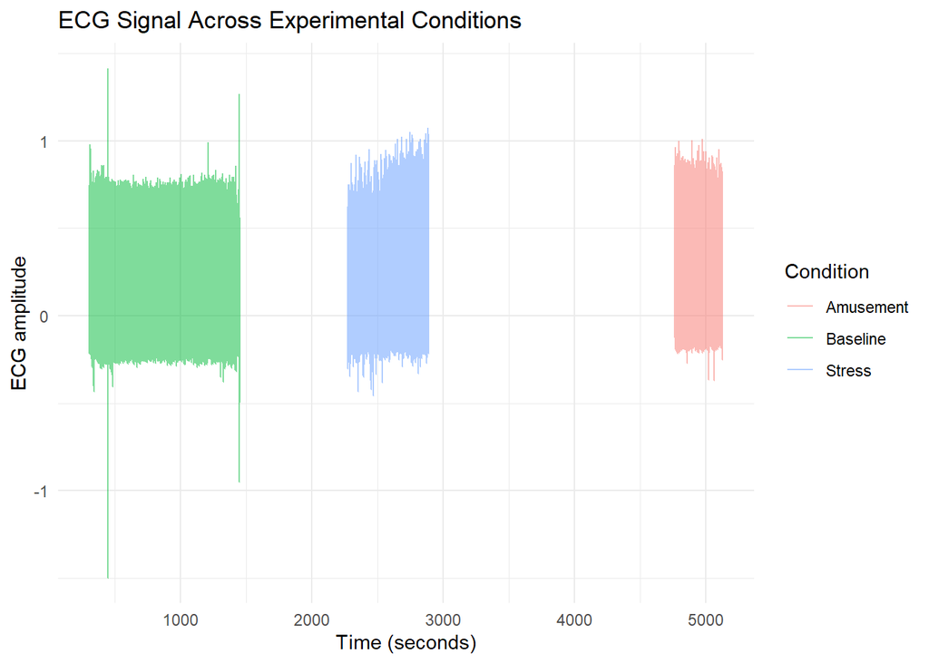

```r
ecg_data %>%
  filter(
    condition %in% c(
      "Baseline",
      "Stress",
      "Amusement"
    )
  ) %>%
  ggplot(
    aes(
      x = time,
      y = ecg,
      color = condition
    )
  ) +
  geom_line(alpha = 0.5) +
  labs(
    title = "ECG Signal Across Experimental Conditions",
    x = "Time (seconds)",
    y = "ECG amplitude",
    color = "Condition"
  ) +
  theme_minimal()
```

# Summary

This exploratory analysis confirms the structure and characteristics of the WESAD ECG recordings. The data consist of high-frequency physiological measurements collected longitudinally across multiple experimental conditions.

Because physiological signals are temporally dependent, subsequent analyses will focus on preprocessing, heart rate extraction, heart rate variability analysis, and functional representations of physiological responses.